# Africa’s Bilateral Debt Network: Financial Integration, Concentration and Economic Centrality (2014–2024)

Network Analysis Project

# 1 Research question and data

This study examines the evolution of Africa’s bilateral public and publicly guaranteed (PPG) external debt network between 2014 and 2024. Creditors are connected to African debtors through directed links, weighted by outstanding bilateral debt in current US dollars. The analysis examines creditor exposure, financial connectivity, regional integration, concentration, community structure and economic correlates of centrality. Financial integration here refers only to bilateral PPG external-debt relationships, not the entire financial system. The empirical results are calculated directly from the supplied data each time this report is knitted.

```
## World Bank IDS source: ea003755-8425-461c-9778-86a0bfdaca1f_Data.csv
```

Dataset and network coverage

| Metric | Value |
| --- | --- |
| Years | 2014–2024 |
| African debtors with observed values | 50 |
| Distinct creditors with positive exposure | 38 |
| Positive annual links | 4897 |
| Conflicting duplicate keys | 0 |

# 2 Global–Africa and intra-African networks

The global network identifies external creditors and African debtors. The intra-African subnetwork isolates creditor–debtor relationships in which both countries are African.

Annual debt-network structure

| Year | Links | Creditors | Debtors | Intra_African_Links | Debt_USD_Billion |
| --- | --- | --- | --- | --- | --- |
| 2014 | 443 | 37 | 49 | 56 | 92.33 |
| 2015 | 441 | 35 | 49 | 54 | 103.15 |
| 2016 | 443 | 34 | 49 | 54 | 114.23 |
| 2017 | 437 | 34 | 49 | 55 | 126.64 |
| 2018 | 436 | 34 | 49 | 53 | 135.00 |
| 2019 | 445 | 35 | 50 | 53 | 141.84 |
| 2020 | 450 | 35 | 50 | 52 | 150.03 |
| 2021 | 451 | 35 | 50 | 53 | 148.57 |
| 2022 | 452 | 34 | 50 | 53 | 145.89 |
| 2023 | 451 | 34 | 50 | 53 | 146.77 |
| 2024 | 448 | 34 | 50 | 52 | 137.38 |

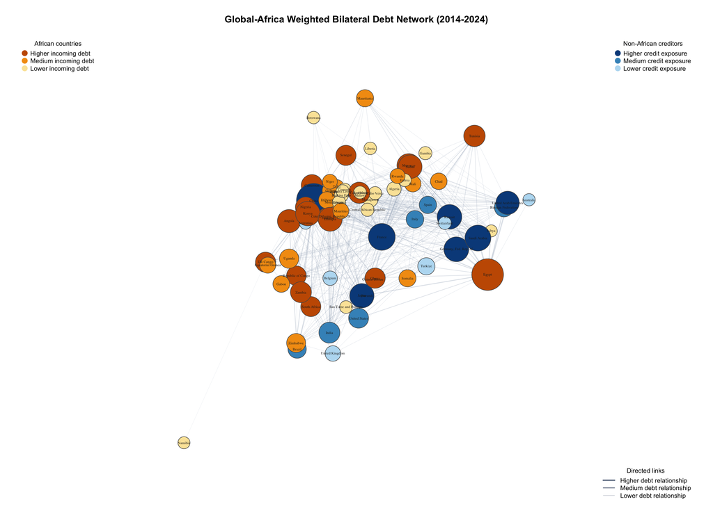

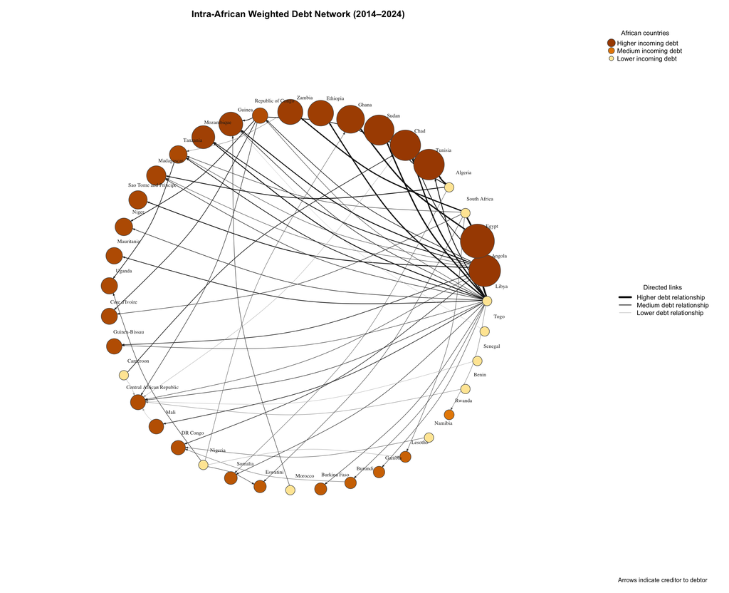

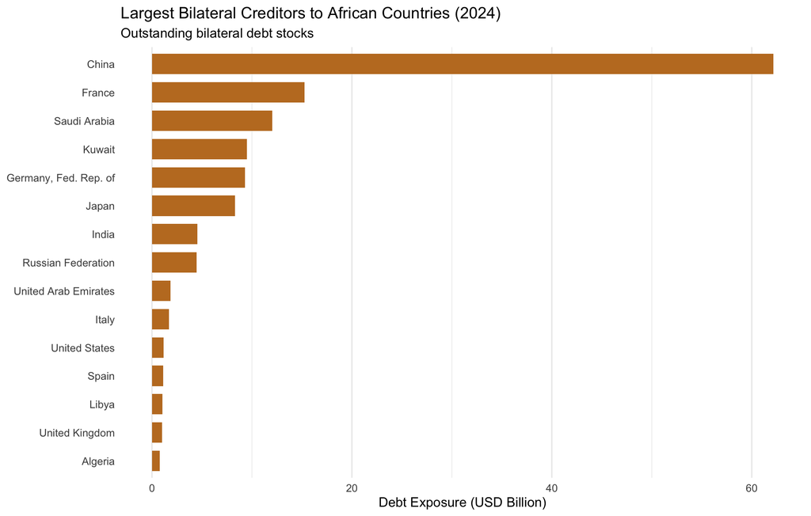

Top 15 African debtors

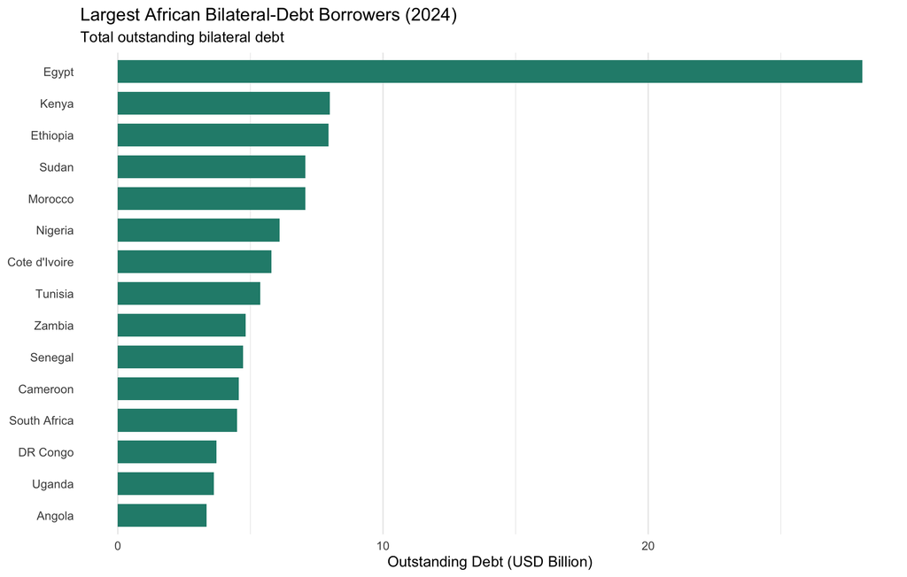

Top 20 African Countries by Bilateral Debt Stock (2024)

| Country | Total_Debt_USD_Bn | Number_Creditors |
| --- | --- | --- |
| Egypt | 28.07 | 12 |
| Kenya | 7.99 | 12 |
| Ethiopia | 7.94 | 13 |
| Sudan | 7.08 | 18 |
| Morocco | 7.07 | 10 |
| Nigeria | 6.10 | 5 |
| Cote d’Ivoire | 5.79 | 10 |
| Tunisia | 5.37 | 14 |
| Zambia | 4.82 | 11 |
| Senegal | 4.72 | 13 |
| Cameroon | 4.56 | 12 |
| South Africa | 4.49 | 3 |
| DR Congo | 3.71 | 7 |
| Uganda | 3.63 | 13 |
| Angola | 3.35 | 8 |
| Ghana | 3.22 | 15 |
| Tanzania | 2.96 | 12 |
| Zimbabwe | 2.93 | 13 |
| Mozambique | 2.69 | 13 |
| Republic of Congo | 2.28 | 12 |

```
## # A tibble: 1 × 4
##   Country Total_Debt_USD_Bn Number_Creditors  Rank
##   <chr>               <dbl>            <int> <int>
## 1 Egypt                28.1               12     1
```

```
## # A tibble: 12 × 2
##    Creditor              Debt_USD_Bn
##    <chr>                       <dbl>
##  1 Saudi Arabia                6.49
##  2 Kuwait                      5.85
##  3 Russian Federation          4.08
##  4 China                       3.58
##  5 Germany, Fed. Rep. of       3.50
##  6 Japan                       2.45
##  7 France                      1.58
##  8 Spain                       0.284
##  9 United States               0.095
## 10 United Arab Emirates        0.091
## 11 United Kingdom              0.05
## 12 Italy                       0.031
```

Intra-African bilateral debt

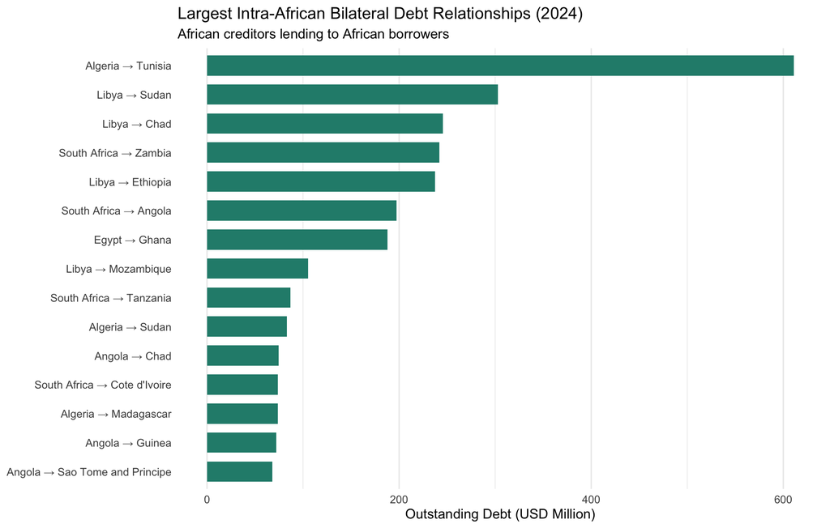

Centrality and financial exposure

In-degree counts distinct creditor relationships for an African debtor; in-strength measures the outstanding debt stock across these relationships. Out-degree and out-strength describe the corresponding lending side. Both unweighted and debt-weighted eigenvector centrality are calculated on the undirected projection. This distinguishes structural connectivity from connectivity to nodes linked by large financial exposures. Node strength is measured in US dollars and is distinct from degree.

Table 3. African countries: degree, node strength (USD billion) and weighted/unweighted eigenvector centrality

| Country | Years | IN | OUT | DEG | EIGEN | EIGEN_weighted | In_strength_USD_Bn | Out_strength_USD_Bn |
| --- | --- | --- | --- | --- | --- | --- | --- | --- |
| Egypt | 11 | 13.909 | 1.000 | 14.909 | 0.481 | 0.836 | 31.671 | 0.306 |
| Kenya | 11 | 12.818 | 0.000 | 12.818 | 0.479 | 0.381 | 8.559 | 0.000 |
| Ethiopia | 11 | 11.182 | 0.000 | 11.182 | 0.413 | 0.358 | 7.263 | 0.000 |
| Sudan | 11 | 18.000 | 0.000 | 18.000 | 0.571 | 0.187 | 7.165 | 0.000 |
| Morocco | 11 | 10.545 | 1.000 | 11.545 | 0.431 | 0.146 | 6.915 | 0.007 |
| Angola | 11 | 9.182 | 9.000 | 18.182 | 0.505 | 0.245 | 5.604 | 0.406 |
| Cameroon | 11 | 11.636 | 1.818 | 13.455 | 0.477 | 0.205 | 4.463 | 0.031 |
| Tunisia | 11 | 13.727 | 0.000 | 13.727 | 0.484 | 0.063 | 4.442 | 0.000 |
| Cote d’Ivoire | 11 | 9.273 | 0.000 | 9.273 | 0.386 | 0.171 | 4.184 | 0.000 |
| Zambia | 11 | 9.364 | 0.091 | 9.455 | 0.362 | 0.190 | 3.795 | 0.000 |
| Nigeria | 11 | 4.727 | 3.182 | 7.909 | 0.278 | 0.198 | 3.669 | 0.014 |
| Ghana | 11 | 14.182 | 0.000 | 14.182 | 0.482 | 0.153 | 3.460 | 0.000 |
| Senegal | 11 | 12.727 | 1.000 | 13.727 | 0.501 | 0.112 | 3.350 | 0.000 |
| Tanzania | 11 | 12.909 | 1.000 | 13.909 | 0.496 | 0.138 | 3.334 | 0.035 |
| DR Congo | 11 | 8.636 | 0.000 | 8.636 | 0.343 | 0.185 | 3.251 | 0.000 |
| Mozambique | 11 | 12.909 | 0.000 | 12.909 | 0.473 | 0.119 | 2.928 | 0.000 |
| Republic of Congo | 11 | 12.455 | 4.455 | 16.909 | 0.536 | 0.147 | 2.895 | 0.183 |
| Uganda | 11 | 9.455 | 0.000 | 9.455 | 0.365 | 0.121 | 2.578 | 0.000 |
| South Africa | 11 | 2.727 | 4.000 | 6.727 | 0.207 | 0.138 | 2.494 | 0.701 |
| Zimbabwe | 11 | 13.000 | 0.000 | 13.000 | 0.419 | 0.106 | 2.479 | 0.000 |

Main creditors ranked by mean annual outstanding bilateral exposure

| from | Mean_connections | Mean_exposure_USD_Bn |
| --- | --- | --- |
| China | 45.64 | 55.97 |
| France | 38.00 | 13.28 |
| Saudi Arabia | 40.27 | 11.24 |
| Germany, Fed. Rep. of | 18.09 | 9.04 |
| Kuwait | 42.91 | 8.70 |
| Japan | 23.55 | 8.00 |
| United Arab Emirates | 25.09 | 6.08 |
| India | 38.64 | 3.99 |
| United States | 14.27 | 2.75 |
| Libya | 18.55 | 1.75 |
| Russian Federation | 10.00 | 1.69 |
| Italy | 17.18 | 1.58 |
| Spain | 21.27 | 1.54 |
| Brazil | 9.09 | 1.10 |
| Turkiye | 7.09 | 0.90 |

Evolution of debt and the COVID period

The following plots compare debt stocks and network connectivity before COVID (2014–2019), during COVID (2020–2021), and after COVID (2022–2024).

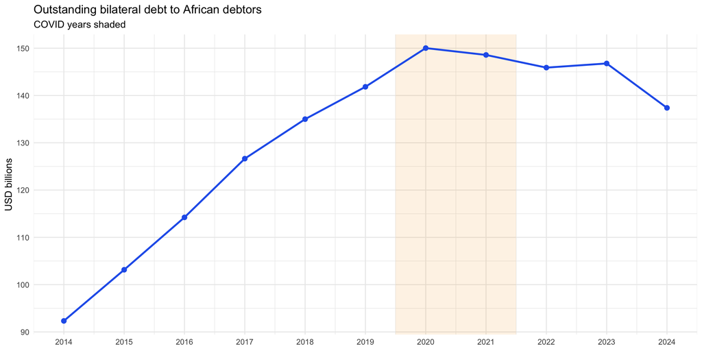

Period averages for the observed bilateral debt network

| Period | Mean_debt_USD_Bn | Mean_links | Mean_creditors |
| --- | --- | --- | --- |
| COVID (2020–2021) | 149.30 | 450.50 | 35.00 |
| Post-COVID (2022–2024) | 143.35 | 450.33 | 34.00 |
| Pre-COVID (2014–2019) | 118.86 | 440.83 | 34.83 |

```
## The observed bilateral debt stock changed by -3.1% between 2019 and 2024. This is a stock comparison and does not measure new lending.
```

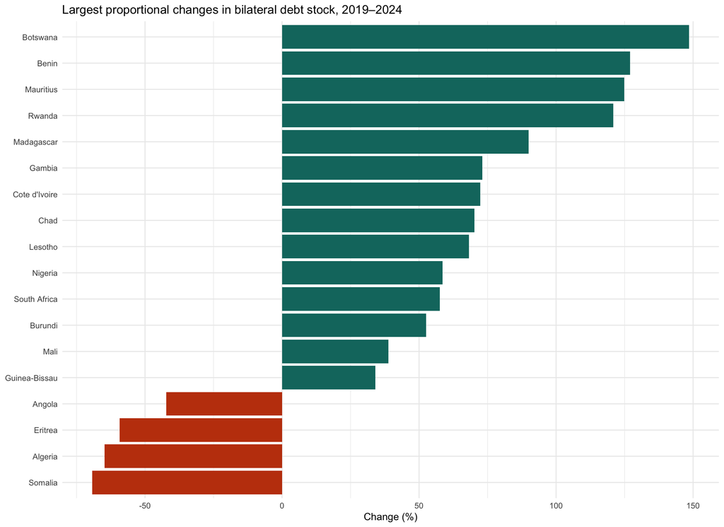

Creditor concentration and dependence

Annual creditor concentration among African debtors with positive bilateral debt

| Year | Mean_HHI | Median_HHI | Mean_largest_share | Countries |
| --- | --- | --- | --- | --- |
| 2014 | 0.363 | 0.316 | 0.494 | 49 |
| 2015 | 0.382 | 0.350 | 0.517 | 49 |
| 2016 | 0.376 | 0.332 | 0.507 | 49 |
| 2017 | 0.372 | 0.322 | 0.506 | 49 |
| 2018 | 0.383 | 0.346 | 0.525 | 49 |
| 2019 | 0.405 | 0.366 | 0.546 | 50 |
| 2020 | 0.406 | 0.376 | 0.548 | 50 |
| 2021 | 0.408 | 0.369 | 0.550 | 50 |
| 2022 | 0.407 | 0.339 | 0.547 | 50 |
| 2023 | 0.413 | 0.347 | 0.550 | 50 |
| 2024 | 0.415 | 0.326 | 0.553 | 50 |

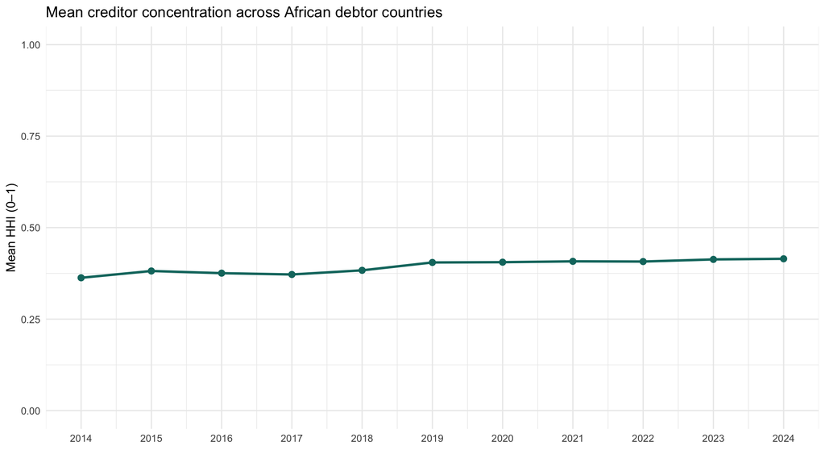

Most concentrated African bilateral creditor portfolios in 2024

| Country | Number_creditors | HHI | Largest_creditor_share | Top_creditor | Debt_USD_Bn |
| --- | --- | --- | --- | --- | --- |
| Equatorial Guinea | 2 | 1.000 | 1.000 | China | 0.829 |
| Botswana | 2 | 0.952 | 0.975 | Japan | 0.120 |
| DR Congo | 7 | 0.900 | 0.948 | China | 3.713 |
| Nigeria | 5 | 0.771 | 0.872 | China | 6.098 |
| Lesotho | 5 | 0.693 | 0.825 | China | 0.220 |
| Djibouti | 10 | 0.636 | 0.789 | China | 1.790 |
| Eswatini | 9 | 0.634 | 0.789 | China | 0.270 |
| Angola | 8 | 0.617 | 0.776 | China | 3.346 |
| Ethiopia | 13 | 0.586 | 0.761 | China | 7.940 |
| South Africa | 3 | 0.584 | 0.742 | China | 4.489 |
| Guinea | 10 | 0.576 | 0.750 | China | 1.523 |
| Zambia | 11 | 0.561 | 0.741 | China | 4.819 |
| Cameroon | 12 | 0.548 | 0.709 | China | 4.562 |
| Gabon | 3 | 0.526 | 0.616 | China | 1.303 |
| Sao Tome and Principe | 4 | 0.521 | 0.661 | Angola | 0.103 |
| Uganda | 13 | 0.521 | 0.708 | China | 3.626 |
| Republic of Congo | 12 | 0.504 | 0.699 | China | 2.277 |
| Zimbabwe | 13 | 0.486 | 0.685 | China | 2.929 |
| Kenya | 12 | 0.483 | 0.671 | China | 7.994 |
| Cote d’Ivoire | 10 | 0.476 | 0.651 | China | 5.795 |

# 3 Creditor groups and the role of China

We compare China with other observed bilateral creditors. These are outstanding stocks, not annual Chinese loan commitments. Creditor classifications are descriptive and should not be interpreted as formal Paris Club membership.

Bilateral debt stock by creditor group in benchmark years

| Year | Group | Debt_USD_Bn | Share |
| --- | --- | --- | --- |
| 2014 | China | 31.552 | 0.342 |
| 2014 | Selected Western/Japanese creditors | 26.881 | 0.291 |
| 2014 | Selected Gulf/Arab creditors | 15.132 | 0.164 |
| 2014 | Other bilateral creditors | 13.000 | 0.141 |
| 2014 | African creditors | 5.765 | 0.062 |
| 2019 | China | 64.562 | 0.455 |
| 2019 | Selected Gulf/Arab creditors | 29.553 | 0.208 |
| 2019 | Selected Western/Japanese creditors | 27.251 | 0.192 |
| 2019 | Other bilateral creditors | 17.190 | 0.121 |
| 2019 | African creditors | 3.282 | 0.023 |
| 2024 | China | 62.153 | 0.452 |
| 2024 | Selected Western/Japanese creditors | 29.196 | 0.213 |
| 2024 | Selected Gulf/Arab creditors | 23.382 | 0.170 |
| 2024 | Other bilateral creditors | 19.479 | 0.142 |
| 2024 | African creditors | 3.173 | 0.023 |

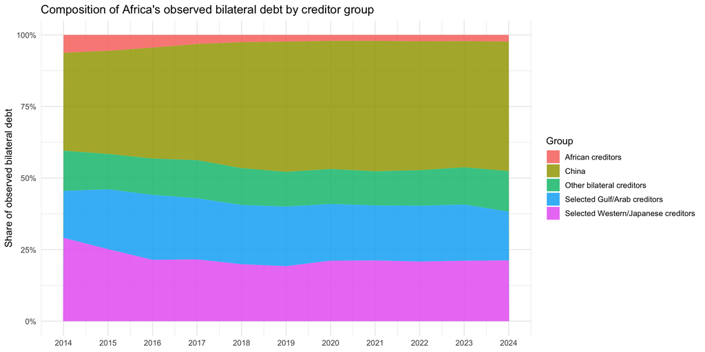

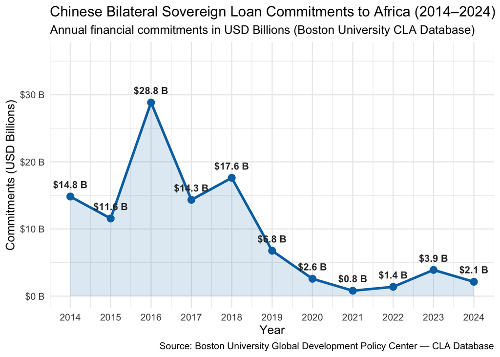

Regional and global financial integration

Financial integration is evaluated through the geography and diversification of bilateral debt relationships. The regional share measures outstanding debt owed to African creditors, while the external share measures debt owed to creditors outside Africa.

Regional and external shares of bilateral PPG debt in benchmark years

| Year | Creditor_origin | Debt_USD_Bn | Links | Creditors | Share |
| --- | --- | --- | --- | --- | --- |
| 2014 | African creditors | 5.765 | 56 | 17 | 0.062 |
| 2014 | Non-African creditors | 86.566 | 387 | 20 | 0.938 |
| 2019 | African creditors | 3.282 | 53 | 16 | 0.023 |
| 2019 | Non-African creditors | 138.556 | 392 | 19 | 0.977 |
| 2024 | African creditors | 3.173 | 52 | 15 | 0.023 |
| 2024 | Non-African creditors | 134.210 | 396 | 19 | 0.977 |

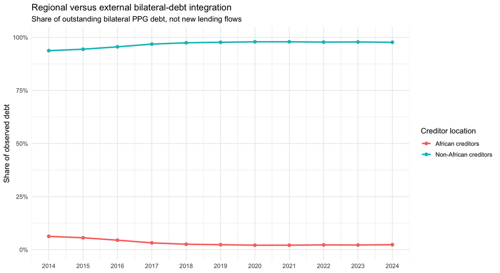

A country-level comparison identifies which African debtors have regional creditor relationships and whether the overall trend is shared across countries.

Debtor-level regional integration: country averages and participation

| Year | Mean_regional_share | Median_regional_share | Debtors_with_regional_creditor | Observed_debtors |
| --- | --- | --- | --- | --- |
| 2014 | 0.072 | 0.012 | 29 | 49 |
| 2015 | 0.067 | 0.011 | 29 | 49 |
| 2016 | 0.063 | 0.010 | 29 | 49 |
| 2017 | 0.058 | 0.010 | 29 | 49 |
| 2018 | 0.057 | 0.007 | 28 | 49 |
| 2019 | 0.051 | 0.006 | 27 | 50 |
| 2020 | 0.048 | 0.002 | 26 | 50 |
| 2021 | 0.051 | 0.006 | 27 | 50 |
| 2022 | 0.053 | 0.006 | 27 | 50 |
| 2023 | 0.050 | 0.006 | 28 | 50 |
| 2024 | 0.048 | 0.004 | 27 | 50 |

African debtor countries with the highest regional creditor share, 2024

| Country | Regional_share | African_creditor_count | External_creditor_count | Total_debt_USD_Bn |
| --- | --- | --- | --- | --- |
| Sao Tome and Principe | 0.661 | 1 | 3 | 0.103 |
| Guinea-Bissau | 0.436 | 2 | 5 | 0.121 |
| Chad | 0.269 | 4 | 7 | 1.458 |
| Central African Republic | 0.156 | 8 | 7 | 0.199 |
| Tunisia | 0.123 | 2 | 12 | 5.368 |
| Niger | 0.094 | 2 | 7 | 0.601 |
| Madagascar | 0.092 | 2 | 10 | 0.832 |
| Guinea | 0.065 | 3 | 7 | 1.523 |
| Mozambique | 0.062 | 2 | 11 | 2.689 |
| Angola | 0.059 | 1 | 7 | 3.346 |
| Ghana | 0.059 | 2 | 13 | 3.218 |
| Sudan | 0.055 | 2 | 16 | 7.078 |
| Zambia | 0.050 | 1 | 10 | 4.819 |
| Somalia | 0.032 | 2 | 5 | 0.396 |
| Tanzania | 0.030 | 2 | 10 | 2.964 |

Financial connectivity and creditor diversification

SonA larger number of creditor links does not necessarily mean a diversified portfolio. The HHI is compared with in-degree and regional exposure to distinguish network integration from concentration.

Cross-country correlations: connectivity, regional integration and creditor concentration

| Year | Correlation_degree_HHI | Correlation_regional_HHI | N |
| --- | --- | --- | --- |
| 2014 | -0.367 | -0.214 | 49 |
| 2015 | -0.306 | -0.199 | 49 |
| 2016 | -0.234 | -0.191 | 49 |
| 2017 | -0.242 | -0.165 | 49 |
| 2018 | -0.266 | -0.073 | 49 |
| 2019 | -0.356 | -0.069 | 50 |
| 2020 | -0.393 | -0.068 | 50 |
| 2021 | -0.407 | -0.067 | 50 |
| 2022 | -0.376 | -0.127 | 50 |
| 2023 | -0.404 | -0.151 | 50 |
| 2024 | -0.435 | -0.121 | 50 |

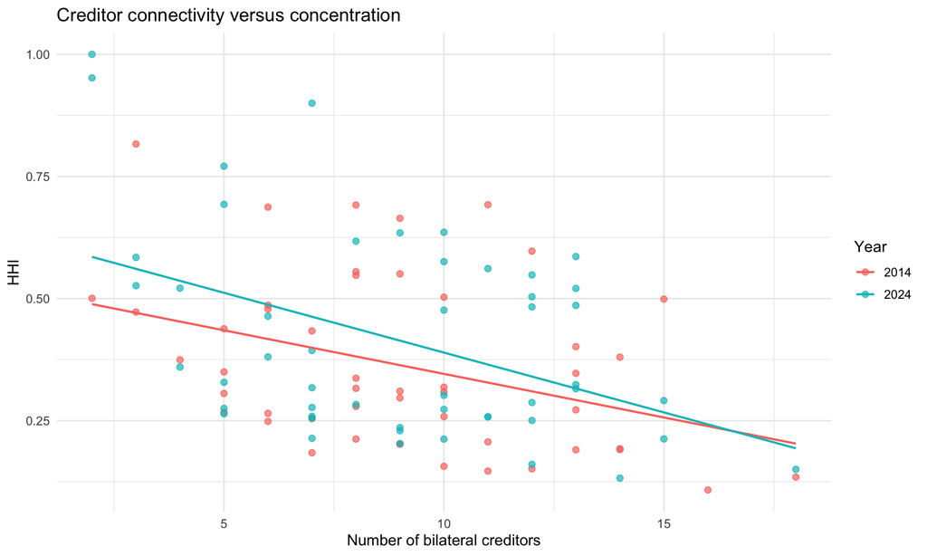

Communities and creditor-profile clusters

Louvain communities are calculated on a weighted undirected projection of the debt network, while the original debt links remain directed. Separately, Ward’s hierarchical clustering groups African debtors by their creditor shares. Four clusters are retained to make the 2014, 2019 and 2024 profiles comparable in number, cluster numbers do not necessarily represent the same composition across years.

Louvain communities in the global–Africa network, 2024

| Country | Community |
| --- | --- |
| Algeria | 1 |
| Botswana | 1 |
| Cabo Verde | 1 |
| Egypt | 1 |
| Eritrea | 1 |
| Gambia | 1 |
| Germany, Fed. Rep. of | 1 |
| Italy | 1 |
| Japan | 1 |
| Kuwait | 1 |
| Liberia | 1 |
| Mauritania | 1 |
| Morocco | 1 |
| Russian Federation | 1 |
| Saudi Arabia | 1 |
| Sierra Leone | 1 |
| Somalia | 1 |
| Spain | 1 |
| Sudan | 1 |
| Switzerland | 1 |
| Tunisia | 1 |
| Angola | 2 |
| Cameroon | 2 |
| China | 2 |
| Cote d’Ivoire | 2 |
| DR Congo | 2 |
| Djibouti | 2 |
| Equatorial Guinea | 2 |
| Eswatini | 2 |
| Ethiopia | 2 |
| Guinea | 2 |
| Kenya | 2 |
| Lesotho | 2 |
| Mozambique | 2 |
| Namibia | 2 |
| Nigeria | 2 |
| Republic of Congo | 2 |
| Sao Tome and Principe | 2 |
| South Africa | 2 |
| Togo | 2 |
| Uganda | 2 |
| United Kingdom | 2 |
| Zambia | 2 |
| Zimbabwe | 2 |
| Argentina | 3 |
| Belgium | 3 |
| Benin | 3 |
| Brazil | 3 |
| Burkina Faso | 3 |
| Burundi | 3 |
| Central African Republic | 3 |
| Comoros | 3 |
| Cote D`Ivoire, Republic Of | 3 |
| France | 3 |
| Gabon | 3 |
| Ghana | 3 |
| Guinea-Bissau | 3 |
| India | 3 |
| Madagascar | 3 |
| Malawi | 3 |
| Mauritius | 3 |
| Niger | 3 |
| Rwanda | 3 |
| Senegal | 3 |
| Tanzania | 3 |
| Turkiye | 3 |
| United States | 3 |
| Chad | 4 |
| Libya | 4 |
| Mali | 4 |
| United Arab Emirates | 4 |

Louvain communities in the intra-African network, 2024

| Country | Community |
| --- | --- |
| Algeria | 1 |
| Madagascar | 1 |
| Tunisia | 1 |
| Angola | 2 |
| Benin | 2 |
| Central African Republic | 2 |
| Cote d’Ivoire | 2 |
| DR Congo | 2 |
| Eswatini | 2 |
| Guinea | 2 |
| Guinea-Bissau | 2 |
| Morocco | 2 |
| Namibia | 2 |
| Nigeria | 2 |
| Sao Tome and Principe | 2 |
| Senegal | 2 |
| South Africa | 2 |
| Tanzania | 2 |
| Uganda | 2 |
| Zambia | 2 |
| Burkina Faso | 3 |
| Burundi | 3 |
| Cameroon | 3 |
| Chad | 3 |
| Ethiopia | 3 |
| Gambia | 3 |
| Libya | 3 |
| Mali | 3 |
| Mauritania | 3 |
| Mozambique | 3 |
| Niger | 3 |
| Republic of Congo | 3 |
| Rwanda | 3 |
| Somalia | 3 |
| Sudan | 3 |
| Egypt | 4 |
| Ghana | 4 |

The modularity score $Q$ evaluates whether within-community connections are stronger than expected under the modularity null model. Annual Louvain partitions are compared separately for the global and intra-African networks. An increase in $Q$ indicates stronger community structure under this method, not necessarily political polarization or causal fragmentation.

Annual weighted Louvain modularity for the two network definitions

| Year | Network | Modularity |
| --- | --- | --- |
| 2014 | Global–Africa | 0.373 |
| 2015 | Global–Africa | 0.388 |
| 2016 | Global–Africa | 0.366 |
| 2017 | Global–Africa | 0.355 |
| 2018 | Global–Africa | 0.338 |
| 2019 | Global–Africa | 0.333 |
| 2020 | Global–Africa | 0.338 |
| 2021 | Global–Africa | 0.328 |
| 2022 | Global–Africa | 0.328 |
| 2023 | Global–Africa | 0.329 |
| 2024 | Global–Africa | 0.318 |
| 2014 | Intra-African | 0.411 |
| 2015 | Intra-African | 0.429 |
| 2016 | Intra-African | 0.440 |
| 2017 | Intra-African | 0.452 |
| 2018 | Intra-African | 0.541 |
| 2019 | Intra-African | 0.532 |
| 2020 | Intra-African | 0.509 |
| 2021 | Intra-African | 0.521 |
| 2022 | Intra-African | 0.555 |
| 2023 | Intra-African | 0.577 |
| 2024 | Intra-African | 0.583 |

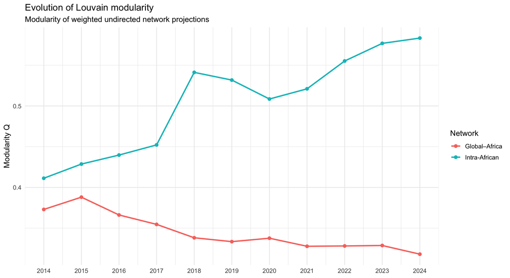

Debtor cluster memberships based on bilateral creditor shares

| Year | Country | Cluster |
| --- | --- | --- |
| 2014 | Algeria | Cluster 1 |
| 2019 | Algeria | Cluster 1 |
| 2024 | Algeria | Cluster 1 |
| 2014 | Angola | Cluster 2 |
| 2019 | Angola | Cluster 2 |
| 2024 | Angola | Cluster 2 |
| 2014 | Benin | Cluster 3 |
| 2019 | Benin | Cluster 2 |
| 2024 | Benin | Cluster 1 |
| 2014 | Botswana | Cluster 3 |
| 2019 | Botswana | Cluster 1 |
| 2024 | Botswana | Cluster 1 |
| 2014 | Burkina Faso | Cluster 1 |
| 2019 | Burkina Faso | Cluster 1 |
| 2024 | Burkina Faso | Cluster 1 |
| 2014 | Burundi | Cluster 4 |
| 2019 | Burundi | Cluster 3 |
| 2024 | Burundi | Cluster 3 |
| 2014 | Cabo Verde | Cluster 1 |
| 2019 | Cabo Verde | Cluster 1 |
| 2024 | Cabo Verde | Cluster 1 |
| 2014 | Cameroon | Cluster 2 |
| 2019 | Cameroon | Cluster 2 |
| 2024 | Cameroon | Cluster 2 |
| 2014 | Central African Republic | Cluster 2 |
| 2019 | Central African Republic | Cluster 3 |
| 2024 | Central African Republic | Cluster 3 |
| 2014 | Chad | Cluster 3 |
| 2019 | Chad | Cluster 2 |
| 2024 | Chad | Cluster 1 |

[output cut: 119 more lines]

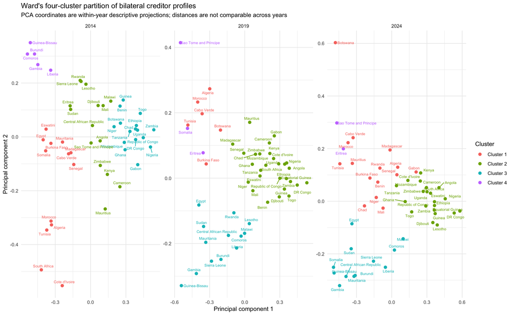

Largest mean creditor shares in each cluster (among cluster countries with the creditor present)

| Year | Cluster | from | Mean_creditor_share |
| --- | --- | --- | --- |
| 2014 | Cluster 1 | France | 0.284 |
| 2014 | Cluster 1 | Russian Federation | 0.173 |
| 2014 | Cluster 1 | Japan | 0.135 |
| 2014 | Cluster 2 | Angola | 0.491 |
| 2014 | Cluster 2 | China | 0.412 |
| 2014 | Cluster 2 | Republic of Congo | 0.187 |
| 2014 | Cluster 3 | China | 0.689 |
| 2014 | Cluster 3 | Egypt | 0.131 |
| 2014 | Cluster 3 | South Africa | 0.107 |
| 2014 | Cluster 4 | Kuwait | 0.361 |
| 2014 | Cluster 4 | Saudi Arabia | 0.326 |
| 2014 | Cluster 4 | India | 0.224 |
| 2019 | Cluster 1 | Japan | 0.266 |
| 2019 | Cluster 1 | France | 0.246 |
| 2019 | Cluster 1 | Cote D`Ivoire, Republic Of | 0.144 |
| 2019 | Cluster 2 | China | 0.670 |
| 2019 | Cluster 2 | Algeria | 0.168 |
| 2019 | Cluster 2 | France | 0.104 |
| 2019 | Cluster 3 | China | 0.326 |
| 2019 | Cluster 3 | Saudi Arabia | 0.219 |
| 2019 | Cluster 3 | Kuwait | 0.188 |
| 2019 | Cluster 4 | Angola | 0.724 |
| 2019 | Cluster 4 | Russian Federation | 0.302 |
| 2019 | Cluster 4 | Italy | 0.252 |
| 2024 | Cluster 1 | China | 0.275 |
| 2024 | Cluster 1 | France | 0.260 |
| 2024 | Cluster 1 | Japan | 0.205 |
| 2024 | Cluster 2 | China | 0.724 |
| 2024 | Cluster 2 | France | 0.083 |
| 2024 | Cluster 2 | Japan | 0.059 |
| 2024 | Cluster 3 | Saudi Arabia | 0.277 |
| 2024 | Cluster 3 | China | 0.261 |
| 2024 | Cluster 3 | Angola | 0.252 |
| 2024 | Cluster 4 | Angola | 0.661 |
| 2024 | Cluster 4 | Italy | 0.472 |
| 2024 | Cluster 4 | United States | 0.131 |

# 4 Changes in creditor-profile clusters

```
##
##
## Table: Creditor-profile cluster transitions, 2014 to 2019
##
## |From      | Cluster 1| Cluster 2| Cluster 3| Cluster 4|
## |:---------|---------:|---------:|---------:|---------:|
## |Cluster 1 |         5|         1|         5|         2|
## |Cluster 2 |         0|         2|         7|         6|
## |Cluster 3 |         1|         0|        15|         0|
## |Cluster 4 |         0|         0|         0|         5|
##
##
## Table: Creditor-profile cluster transitions, 2019 to 2024
##
## |From      | Cluster 1| Cluster 2| Cluster 3| Cluster 4|
## |:---------|---------:|---------:|---------:|---------:|
## |Cluster 1 |         6|         0|         0|         0|
## |Cluster 2 |         0|         2|         0|         1|
## |Cluster 3 |         8|         0|        20|         0|
## |Cluster 4 |         1|         0|         1|        11|
##
##
## Table: Countries that changed aligned creditor-profile clusters
##
## |Country                  |From      |To        |Period    |
## |:------------------------|:---------|:---------|:---------|
## |Angola                   |Cluster 2 |Cluster 3 |2014–2019 |
## |Botswana                 |Cluster 3 |Cluster 1 |2014–2019 |
## |Cameroon                 |Cluster 2 |Cluster 3 |2014–2019 |
## |Central African Republic |Cluster 2 |Cluster 4 |2014–2019 |
## |Cote d'Ivoire            |Cluster 1 |Cluster 3 |2014–2019 |
## |Djibouti                 |Cluster 2 |Cluster 3 |2014–2019 |
## |Egypt                    |Cluster 1 |Cluster 4 |2014–2019 |
## |Eswatini                 |Cluster 1 |Cluster 3 |2014–2019 |
## |Kenya                    |Cluster 2 |Cluster 3 |2014–2019 |
## |Lesotho                  |Cluster 2 |Cluster 4 |2014–2019 |
## |Madagascar               |Cluster 1 |Cluster 3 |2014–2019 |
## |Malawi                   |Cluster 2 |Cluster 4 |2014–2019 |
## |Mali                     |Cluster 2 |Cluster 3 |2014–2019 |
## |Mauritania               |Cluster 1 |Cluster 4 |2014–2019 |
## |Mauritius                |Cluster 2 |Cluster 3 |2014–2019 |
## |Rwanda                   |Cluster 2 |Cluster 4 |2014–2019 |
## |Senegal                  |Cluster 1 |Cluster 3 |2014–2019 |
## |Sierra Leone             |Cluster 2 |Cluster 4 |2014–2019 |
## |Somalia                  |Cluster 1 |Cluster 2 |2014–2019 |
## |South Africa             |Cluster 1 |Cluster 3 |2014–2019 |
## |Sudan                    |Cluster 2 |Cluster 4 |2014–2019 |
## |Zimbabwe                 |Cluster 2 |Cluster 3 |2014–2019 |
## |Benin                    |Cluster 3 |Cluster 1 |2019–2024 |
## |Chad                     |Cluster 3 |Cluster 1 |2019–2024 |
## |Gabon                    |Cluster 3 |Cluster 1 |2019–2024 |
## |Lesotho                  |Cluster 4 |Cluster 3 |2019–2024 |
## |Madagascar               |Cluster 3 |Cluster 1 |2019–2024 |
## |Mali                     |Cluster 3 |Cluster 1 |2019–2024 |
## |Mauritius                |Cluster 3 |Cluster 1 |2019–2024 |
## |Niger                    |Cluster 3 |Cluster 1 |2019–2024 |
## |Rwanda                   |Cluster 4 |Cluster 1 |2019–2024 |
## |Senegal                  |Cluster 3 |Cluster 1 |2019–2024 |
## |Somalia                  |Cluster 2 |Cluster 4 |2019–2024 |
```

```
## Install the optional 'ggalluvial' package to display the flow chart. The transition matrices above remain available.
```

# 5 Core–periphery and k-core structure

The k-core decomposition identifies nodes that belong to increasingly interconnected subsets of the network. It is calculated on the undirected projection of observed creditor–debtor links. High coreness is evidence of embedded connectivity, not a formal statistical test of a core–periphery model; in a predominantly creditor–debtor network, the absence of triangles or reciprocal lending can limit the informative range of k-core scores.

Highest k-core membership in benchmark-year debt networks

| Year | Country | Coreness | Degree | Is_African |
| --- | --- | --- | --- | --- |
| 2014 | Algeria | 10 | 14 | TRUE |
| 2014 | Angola | 10 | 18 | TRUE |
| 2014 | Belgium | 10 | 25 | FALSE |
| 2014 | Cameroon | 10 | 11 | TRUE |
| 2014 | Chad | 10 | 11 | TRUE |
| 2014 | China | 10 | 43 | FALSE |
| 2014 | Egypt | 10 | 17 | TRUE |
| 2014 | France | 10 | 39 | FALSE |
| 2014 | Germany, Fed. Rep. of | 10 | 19 | FALSE |
| 2014 | India | 10 | 36 | FALSE |
| 2014 | Italy | 10 | 17 | FALSE |
| 2014 | Japan | 10 | 20 | FALSE |
| 2014 | Kuwait | 10 | 43 | FALSE |
| 2014 | Libya | 10 | 20 | TRUE |
| 2014 | Morocco | 10 | 12 | TRUE |
| 2019 | Algeria | 9 | 12 | TRUE |
| 2019 | Angola | 9 | 18 | TRUE |
| 2019 | Belgium | 9 | 25 | FALSE |
| 2019 | Cameroon | 9 | 14 | TRUE |
| 2019 | Chad | 9 | 10 | TRUE |
| 2019 | China | 9 | 47 | FALSE |
| 2019 | Egypt | 9 | 15 | TRUE |
| 2019 | France | 9 | 38 | FALSE |
| 2019 | Germany, Fed. Rep. of | 9 | 17 | FALSE |
| 2019 | India | 9 | 39 | FALSE |
| 2019 | Italy | 9 | 17 | FALSE |
| 2019 | Japan | 9 | 24 | FALSE |
| 2019 | Kuwait | 9 | 43 | FALSE |
| 2019 | Libya | 9 | 18 | TRUE |
| 2019 | Mali | 9 | 10 | TRUE |
| 2024 | Algeria | 10 | 11 | TRUE |
| 2024 | Angola | 10 | 18 | TRUE |
| 2024 | Belgium | 10 | 24 | FALSE |
| 2024 | Cameroon | 10 | 14 | TRUE |
| 2024 | Chad | 10 | 12 | TRUE |
| 2024 | China | 10 | 46 | FALSE |
| 2024 | Egypt | 10 | 13 | TRUE |
| 2024 | France | 10 | 37 | FALSE |
| 2024 | Germany, Fed. Rep. of | 10 | 18 | FALSE |
| 2024 | India | 10 | 40 | FALSE |
| 2024 | Italy | 10 | 20 | FALSE |
| 2024 | Japan | 10 | 26 | FALSE |
| 2024 | Kuwait | 10 | 42 | FALSE |
| 2024 | Libya | 10 | 17 | TRUE |
| 2024 | Mali | 10 | 10 | TRUE |

Annual k-core summary in benchmark years

| Year | Max_coreness | Mean_coreness | Nodes |
| --- | --- | --- | --- |
| 2014 | 10 | 7.97 | 71 |
| 2019 | 9 | 7.56 | 71 |
| 2024 | 10 | 8.01 | 71 |

So what makes a country more central?

OLS: log(1 + number of creditors) and bilateral debt stock, with year fixed effects

| Term | Estimate | Std_error | t_value | p_value |
| --- | --- | --- | --- | --- |
| (Intercept) | -0.7801 | 0.1905 | -4.0946 | 0.0000 |
| log_debt | 0.1485 | 0.0091 | 16.3111 | 0.0000 |
| year_factor2015 | -0.0157 | 0.0645 | -0.2440 | 0.8073 |
| year_factor2016 | -0.0266 | 0.0645 | -0.4117 | 0.6807 |
| year_factor2017 | -0.0494 | 0.0646 | -0.7653 | 0.4444 |
| year_factor2018 | -0.0605 | 0.0646 | -0.9366 | 0.3494 |
| year_factor2019 | -0.0805 | 0.0643 | -1.2518 | 0.2112 |
| year_factor2020 | -0.0837 | 0.0644 | -1.3009 | 0.1939 |
| year_factor2021 | -0.0819 | 0.0644 | -1.2718 | 0.2040 |
| year_factor2022 | -0.0775 | 0.0644 | -1.2039 | 0.2292 |
| year_factor2023 | -0.0858 | 0.0644 | -1.3325 | 0.1833 |
| year_factor2024 | -0.0932 | 0.0643 | -1.4481 | 0.1482 |

The estimated coefficient on log outstanding debt is **0.148** (p = 0.0000). Within the pooled country–year sample and conditional on year effects, a 1% higher observed bilateral debt stock is associated with approximately 0.148% higher (1 + number of creditors). The association is statistically distinguishable from zero at the 5% level. The model R-squared is 0.333. These results do not identify a causal effect. To examine whether economic size and other available macroeconomic variables are associated with centrality, an extended specification uses World Bank WDI data. Institutional quality is not estimated because governance data are not included. When a `country_gdp_panel.csv` file containing `Country`, `Year`, `GDP_USD` and optional `GDP_per_capita_USD`, `Trade_open_percent_GDP`, and `FDI_net_inflows_percent_GDP` is available, the report estimates an extended model. GDP is also used to calculate bilateral debt-to-GDP ratios.

```
## Unmatched country-year pairs: 0
```

2024: bilateral PPG debt relative to GDP (percent), top 20

| Country | IN | Bilateral_Debt_USD_Bn | GDP_USD_Bn | Bilateral_debt_to_GDP_percent |
| --- | --- | --- | --- | --- |
| Djibouti | 10 | 1.79 | 4.15 | 43.10 |
| Zambia | 11 | 4.82 | 25.30 | 19.04 |
| Senegal | 13 | 4.72 | 32.17 | 14.66 |
| Republic of Congo | 12 | 2.28 | 15.72 | 14.48 |
| Sudan | 18 | 7.08 | 49.67 | 14.25 |
| Gambia | 7 | 0.34 | 2.40 | 14.20 |
| Mauritania | 10 | 1.37 | 10.88 | 12.63 |
| Sao Tome and Principe | 4 | 0.10 | 0.82 | 12.46 |
| Mozambique | 13 | 2.69 | 22.75 | 11.82 |
| Comoros | 5 | 0.18 | 1.61 | 11.33 |
| Tunisia | 14 | 5.37 | 51.41 | 10.44 |
| Lesotho | 5 | 0.22 | 2.39 | 9.20 |
| Mauritius | 8 | 1.30 | 14.94 | 8.68 |
| Cameroon | 12 | 4.56 | 53.30 | 8.56 |
| Chad | 11 | 1.46 | 19.91 | 7.33 |
| Central African Republic | 15 | 0.20 | 2.75 | 7.24 |
| Egypt | 12 | 28.07 | 389.06 | 7.22 |
| Zimbabwe | 13 | 2.93 | 41.52 | 7.05 |
| Rwanda | 10 | 1.04 | 15.11 | 6.90 |
| Uganda | 13 | 3.63 | 53.91 | 6.73 |

Descriptive OLS with trade openness and FDI controls

| Term | Estimate | Std. Error | t value | Pr(>\|t\|) |
| --- | --- | --- | --- | --- |
| (Intercept) | 0.1082 | 0.2390 | 0.4528 | 0.6509 |
| log_debt | 0.2237 | 0.0145 | 15.4525 | 0.0000 |
| log_GDP | -0.0987 | 0.0148 | -6.6827 | 0.0000 |
| Trade_open_percent_GDP | -0.0011 | 0.0003 | -3.0722 | 0.0022 |
| FDI_net_inflows_percent_GDP | -0.0005 | 0.0029 | -0.1647 | 0.8693 |
| year_factor2015 | -0.0496 | 0.0643 | -0.7710 | 0.4411 |
| year_factor2016 | -0.0711 | 0.0644 | -1.1028 | 0.2707 |
| year_factor2017 | -0.0930 | 0.0642 | -1.4490 | 0.1480 |
| year_factor2018 | -0.0990 | 0.0644 | -1.5368 | 0.1250 |
| year_factor2019 | -0.1240 | 0.0640 | -1.9374 | 0.0533 |
| year_factor2020 | -0.1443 | 0.0643 | -2.2437 | 0.0253 |
| year_factor2021 | -0.1247 | 0.0639 | -1.9527 | 0.0514 |
| year_factor2022 | -0.1022 | 0.0638 | -1.6014 | 0.1100 |
| year_factor2023 | -0.1128 | 0.0638 | -1.7678 | 0.0777 |
| year_factor2024 | -0.1079 | 0.0640 | -1.6854 | 0.0926 |

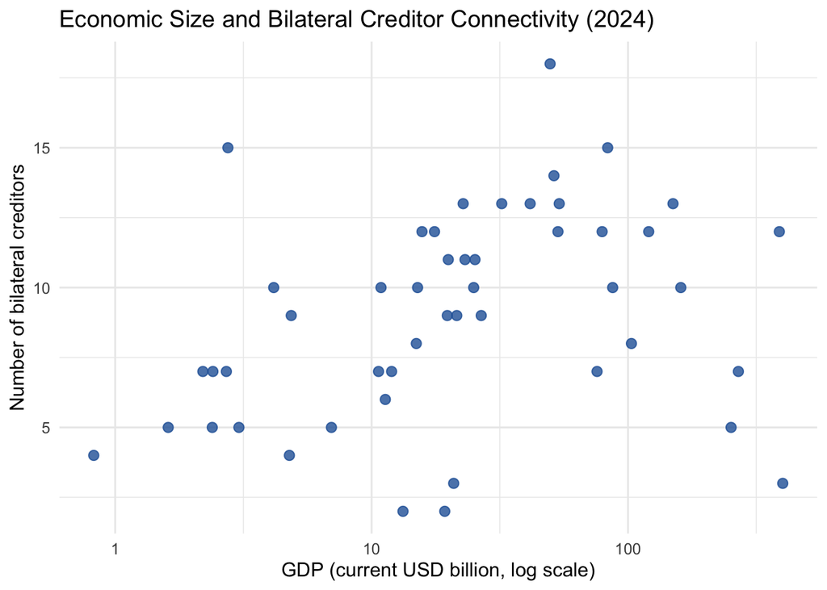

# 6 Betweenness and brokerage

Betweenness centrality identifies nodes positioned along shortest paths. The analysis compares the full directed creditor-to-debtor network with the intra-African subnetwork. Shortest paths are calculated without financial weights: a larger debt amount is an exposure, not a longer distance. Because bilateral debt networks are often creditor–debtor oriented, even large creditors may have zero directed betweenness; positive values should not automatically be interpreted as financial intermediation.

Directed betweenness: benchmark-year global and intra-African networks

| Year | Country | Betweenness | Network |
| --- | --- | --- | --- |
| 2014 | Angola | 73.67 | Global–Africa |
| 2014 | Republic of Congo | 41.50 | Global–Africa |
| 2014 | South Africa | 12.00 | Global–Africa |
| 2014 | Tanzania | 12.00 | Global–Africa |
| 2014 | Algeria | 6.00 | Global–Africa |
| 2014 | Egypt | 6.00 | Global–Africa |
| 2014 | Morocco | 4.17 | Global–Africa |
| 2014 | Senegal | 4.00 | Global–Africa |
| 2014 | Cameroon | 2.17 | Global–Africa |
| 2014 | Nigeria | 2.00 | Global–Africa |
| 2019 | Angola | 58.67 | Global–Africa |
| 2019 | Republic of Congo | 34.00 | Global–Africa |
| 2019 | South Africa | 9.50 | Global–Africa |
| 2019 | Tanzania | 8.50 | Global–Africa |
| 2019 | Cameroon | 7.42 | Global–Africa |
| 2019 | Algeria | 4.50 | Global–Africa |
| 2019 | Egypt | 4.50 | Global–Africa |
| 2019 | Morocco | 3.83 | Global–Africa |
| 2019 | Senegal | 3.33 | Global–Africa |
| 2019 | Nigeria | 2.50 | Global–Africa |
| 2024 | Angola | 50.92 | Global–Africa |
| 2024 | Republic of Congo | 14.57 | Global–Africa |
| 2024 | South Africa | 9.50 | Global–Africa |
| 2024 | Algeria | 7.50 | Global–Africa |
| 2024 | Cameroon | 7.12 | Global–Africa |
| 2024 | Tanzania | 5.00 | Global–Africa |
| 2024 | Morocco | 3.50 | Global–Africa |
| 2024 | Egypt | 3.00 | Global–Africa |
| 2024 | Senegal | 2.48 | Global–Africa |
| 2024 | Benin | 1.78 | Global–Africa |
| 2014 | Angola | 12.00 | Intra-African |
| 2014 | Republic of Congo | 9.00 | Intra-African |
| 2014 | Tanzania | 4.00 | Intra-African |
| 2014 | Egypt | 1.00 | Intra-African |
| 2014 | Zambia | 1.00 | Intra-African |
| 2014 | Algeria | 0.00 | Intra-African |
| 2014 | Benin | 0.00 | Intra-African |
| 2014 | Cameroon | 0.00 | Intra-African |
| 2014 | Chad | 0.00 | Intra-African |
| 2014 | Libya | 0.00 | Intra-African |
| 2019 | Angola | 13.00 | Intra-African |
| 2019 | Republic of Congo | 6.00 | Intra-African |
| 2019 | Tanzania | 3.00 | Intra-African |
| 2019 | Burundi | 1.00 | Intra-African |
| 2019 | Chad | 1.00 | Intra-African |
| 2019 | Algeria | 0.00 | Intra-African |
| 2019 | Benin | 0.00 | Intra-African |
| 2019 | Cameroon | 0.00 | Intra-African |
| 2019 | Egypt | 0.00 | Intra-African |
| 2019 | Libya | 0.00 | Intra-African |
| 2024 | Angola | 10.00 | Intra-African |
| 2024 | Republic of Congo | 2.00 | Intra-African |
| 2024 | Tanzania | 2.00 | Intra-African |
| 2024 | Algeria | 0.00 | Intra-African |
| 2024 | Benin | 0.00 | Intra-African |
| 2024 | Cameroon | 0.00 | Intra-African |
| 2024 | Chad | 0.00 | Intra-African |
| 2024 | Egypt | 0.00 | Intra-African |
| 2024 | Libya | 0.00 | Intra-African |
| 2024 | Mali | 0.00 | Intra-African |

# 7 Network Robustness Analysis (2024)

This section tests the structural importance of individual creditors in the observed 2024 bilateral debt network. Removing a creditor means deleting its creditor-to-debtor links for analytical purposes only; it does not mean cancelling outstanding debt, predicting a withdrawal of funding, or simulating default contagion. We compare network reach, the share of each debtor’s outstanding bilateral debt associated with a creditor, and the concentration of remaining creditor relationships.

2024 creditor-removal stress test: observed connectivity and exposure

| Creditor | Affected_debtors | Links_removed | Exposure_USD_Bn | Max_debtor_exposure_percent | Mean_debtor_exposure_percent | Sole_creditor_debtors |
| --- | --- | --- | --- | --- | --- | --- |
| China | 46 | 46 | 62.15 | 100.00 | 47.20 | 0 |
| Kuwait | 42 | 42 | 9.48 | 35.96 | 8.19 | 0 |
| Saudi Arabia | 41 | 41 | 12.03 | 47.76 | 10.96 | 0 |
| India | 40 | 40 | 4.54 | 31.61 | 7.74 | 0 |
| France | 37 | 37 | 15.24 | 42.03 | 14.30 | 0 |
| United Arab Emirates | 28 | 28 | 1.87 | 44.57 | 4.90 | 0 |
| Japan | 26 | 26 | 8.32 | 97.52 | 12.04 | 0 |
| Belgium | 24 | 24 | 0.51 | 11.50 | 1.53 | 0 |
| Spain | 21 | 21 | 1.14 | 14.98 | 2.17 | 0 |
| Italy | 20 | 20 | 1.68 | 65.88 | 7.74 | 0 |
| Germany, Fed. Rep. of | 18 | 18 | 9.30 | 37.67 | 6.53 | 0 |
| Libya | 17 | 17 | 1.05 | 16.85 | 3.03 | 0 |
| United States | 13 | 13 | 1.16 | 13.09 | 2.54 | 0 |
| Russian Federation | 10 | 10 | 4.48 | 14.54 | 2.55 | 0 |
| Angola | 10 | 10 | 0.40 | 66.14 | 13.10 | 0 |

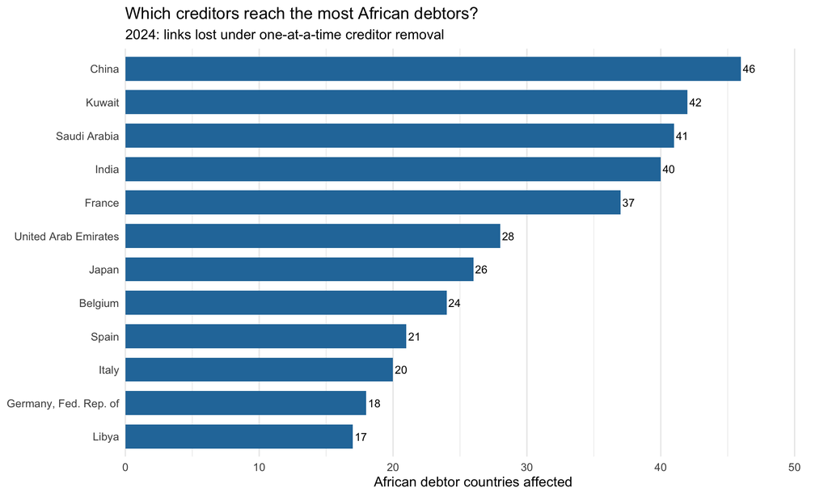

Dependence on individual creditors

The number of links alone can hide large financial dependence. The next figure identifies the largest single-creditor share of each debtor’s observed bilateral PPG debt stock. A country with multiple creditor links can still be highly concentrated.

2024: African countries most dependent on one bilateral creditor

| Country | Main_creditor | Main_creditor_share_percent | Number_creditors | Bilateral_debt_USD_Bn |
| --- | --- | --- | --- | --- |
| Equatorial Guinea | China | 100.00 | 2 | 0.83 |
| Botswana | Japan | 97.52 | 2 | 0.12 |
| DR Congo | China | 94.80 | 7 | 3.71 |
| Nigeria | China | 87.24 | 5 | 6.10 |
| Lesotho | China | 82.53 | 5 | 0.22 |
| Djibouti | China | 78.92 | 10 | 1.79 |
| Eswatini | China | 78.89 | 9 | 0.27 |
| Angola | China | 77.59 | 8 | 3.35 |
| Ethiopia | China | 76.09 | 13 | 7.94 |
| Guinea | China | 74.96 | 10 | 1.52 |
| South Africa | China | 74.19 | 3 | 4.49 |
| Zambia | China | 74.11 | 11 | 4.82 |
| Cameroon | China | 70.94 | 12 | 4.56 |
| Uganda | China | 70.82 | 13 | 3.63 |
| Republic of Congo | China | 69.95 | 12 | 2.28 |
| Zimbabwe | China | 68.53 | 13 | 2.93 |
| Kenya | China | 67.14 | 12 | 7.99 |
| Sao Tome and Principe | Angola | 66.14 | 4 | 0.10 |
| Eritrea | Italy | 65.88 | 6 | 0.06 |
| Cote d’Ivoire | China | 65.09 | 10 | 5.79 |

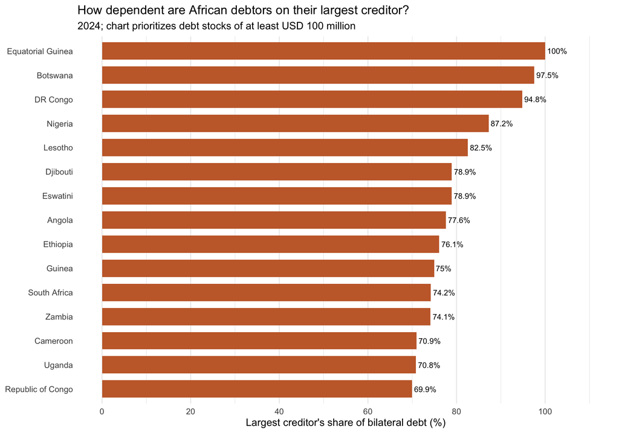

Robustness interpretation

In 2024, **China** has the widest observed creditor reach, with links to **46** African debtor countries. The largest aggregate bilateral exposure belongs to **China** (USD 62.15 billion). Reach and financial exposure are distinct dimensions of network importance.

At the debtor level, **Equatorial Guinea** has the highest observed single-creditor concentration: **China** accounts for **100%** of its bilateral PPG debt stock. A high share indicates creditor concentration, not necessarily imminent distress.

No African debtor with positive observed 2024 bilateral debt has only one creditor in this dataset. Consequently, deleting any single creditor’s links does not isolate a debtor; the isolation chart is omitted because all values would be zero.

**Interpretation limit:** This is a one-step structural robustness exercise, not an Eisenberg–Noe clearing or contagion model. It measures the topology and concentration of existing debt relationships, not the probability of default or the economic effect of losing future credit.

FOr Conclusion

Between 2019 and 2024, the observed bilateral debt stock decreased by 3.1% relative to 2019. This describes changes in outstanding bilateral debt, not annual new commitments.

Average debtor-level creditor concentration changed from **0.363 in 2014** to **0.415 in 2024**. The observed bilateral creditor portfolios became more concentrated on average. The share of observed bilateral debt owed to African creditors changed from **6.2% in 2014** to **2.3% in 2024**. This indicates a smaller regional share of bilateral creditor exposure. The measure does not capture portfolio investment, bank lending or other channels of financial integration.

Weighted global-network Louvain modularity changed from **0.373** to **0.318**. This documents changes in detected community structure, but it is not evidence by itself of geopolitical polarization.

The largest observed creditor by mean annual outstanding exposure was **China** (55.97 USD billion). These rankings should be interpreted alongside the number of debtor relationships: network reach and financial exposure measure different dimensions of creditor importance.

The country–year regression finds a positive association between bilateral debt stock and creditor connectivity (coefficient 0.148). This does not demonstrate that borrowing itself causes centrality: economic size, creditworthiness, access to international finance and creditor strategy may jointly shape both.

Overall, the network approach reveals creditor financial exposure, regional versus external bilateral-debt integration, creditor concentration, community structure and how these patterns evolved around the pandemic. The dataset covers observed bilateral PPG external debt, not all external debt, total government liabilities or repayment capacity. Changes in nominal USD stocks may also reflect exchange rates, valuation and restructuring. Creditor concentration can indicate dependence, but it is not by itself evidence of default risk or systemic contagion.